# Retrieve Endowment Funds

Chi Qiu

2024-04-23

```r
library(tidyverse)
library(kableExtra)
library(lubridate)
library(forcats)
library(here)
library(viridis)
knitr::opts_chunk$set(message = FALSE, warning = FALSE)
```

```r
#######################################
# CREATE BIG PALETTE WITH MANY COLORS
#######################################

pal1 <- viridis_pal(option="mako", end = .9)(12)
pal2 <- viridis_pal(option="rocket", end = .8)(12)
pal3 <- viridis_pal(option="magma", end = .9)(12)
pal4 <- viridis_pal(option="inferno", end = .8)(12)

set.seed(123)
pal <- c(pal1, pal2, pal3, pal4)
indexes <- sample.int(length(pal), replace=FALSE)
pal <- pal[indexes]
```

```r
# make kable table with consistent formatting
make_table <- function(..., title = "", col_names = c("")) {
  title <- paste0("<center><span style = 'font-size:150%;color:black'><b>",
                  title,
                  "</span></b><center>")
   as_tibble(...) %>%
    kbl(caption = title,
        col.names = col_names) %>%
    kable_material() %>%
    row_spec(row=0, background = "#43494C" , color = "white", bold = TRUE)
}
```

> Note: Zero was coded as false and One as true for Checkbox questions.  
> Additional note: Put the companies.csv file into your data folder

```r
endowment_data <- read_rds(here("data", "endowment_filter_data_990.RDS"))
names <- readRDS(here("data","companies.RDS"))
names <- names %>%
  rename(organization_name = Company)
names <- names %>%
  mutate(organization_name = ifelse(
    organization_name == "Ballet Hispanico",
    "Ballet Hispánico",
    organization_name))
```

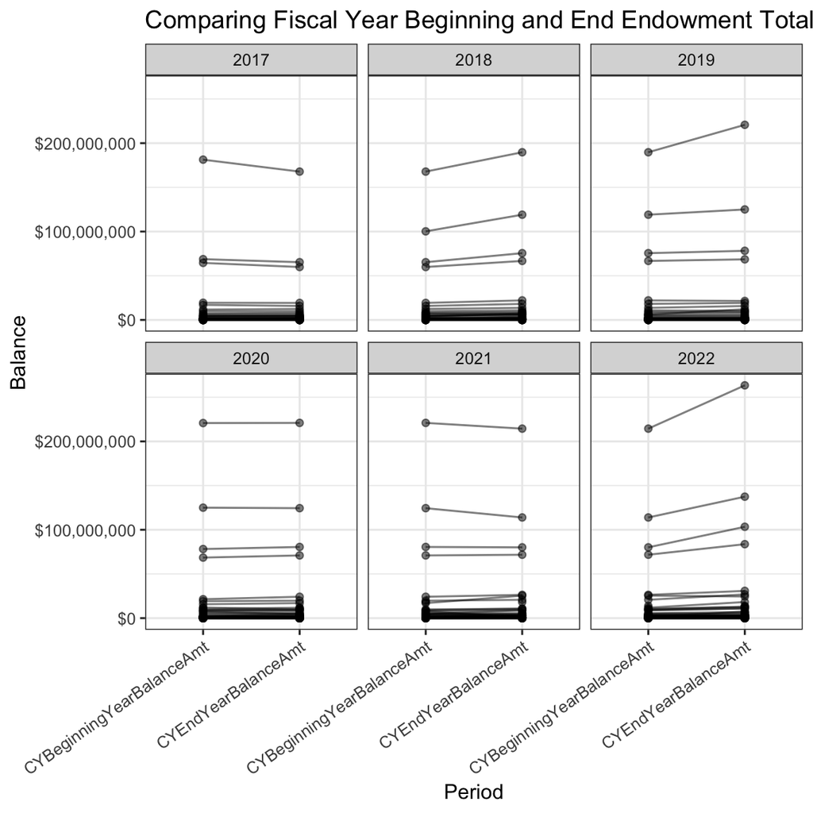

```r
##Graphing difference between beginning and end periods

endowment_data %>%
  select(ReturnDate, EIN, CYBeginningYearBalanceAmt, CYEndYearBalanceAmt) %>%
  pivot_longer(cols = c(CYBeginningYearBalanceAmt, CYEndYearBalanceAmt), names_to = "Period", values_to = "Balance") %>%
  mutate(Period = as.factor(Period)) %>%
  mutate(Year = as.integer(substr(ReturnDate, 1, 4))) %>%
  filter(Year <= 2022) %>% # Filtering to include only data up to 2022
  ggplot(aes(x = Period, y = Balance, group = EIN)) +
  facet_wrap(~Year) +
  geom_point(alpha = 0.5) +
  geom_line(alpha = 0.5) +
  theme_bw() +
  theme(axis.text.x = element_text(angle = 35, hjust =1),
        legend.position = "none") +
  labs(title = "Comparing Fiscal Year Beginning and End Endowment Totals") +
  scale_y_continuous(labels = scales::label_dollar())
```

## Which Years and Companies Filled out Schedule D

```r
##Identifying those that DID fill out schedule D for Endowment, as they supplied info in any numeric column
##Assuming the sum of from cols 4-31 (schedule D finances) is not zero
filed_schd_d <- endowment_data %>%
 mutate(Filled_Sch_D = ifelse(rowSums(across(CYBeginningYearBalanceAmt:TermEndowmentBalanceEOYPct), na.rm = TRUE) != 0, "Yes", "No")) %>%
  select(TaxPeriodBeginDt, TaxPeriodEndDt, ReturnDate, EIN, DonorRstrOrQuasiEndowmentsInd, Filled_Sch_D) %>%
  mutate(Need_Sch_D = case_when(is.na(DonorRstrOrQuasiEndowmentsInd) ~ "NA",
                                DonorRstrOrQuasiEndowmentsInd == TRUE ~ "Yes",
                                DonorRstrOrQuasiEndowmentsInd == FALSE ~ "No")) %>%
  select(-DonorRstrOrQuasiEndowmentsInd)
```

```r
filed_schd_d %>%
  select(EIN, Filled_Sch_D) %>%
  filter(Filled_Sch_D == "Yes") %>%
  group_by(EIN) %>%
  summarize(num_times_fil_sche_D = n()) %>%
  left_join(names, by = "EIN") %>%
  arrange(desc(num_times_fil_sche_D)) %>%
  select(EIN, organization_name, num_times_fil_sche_D) %>%
  make_table(title = "EINs that reported an endowment at least once", col_names = c("EIN", "Organization Name", "# Times an endowment was filled out")) %>%
  scroll_box(height = "450px")
```

**EINs that reported an endowment at least once**

| EIN | Organization Name | # Times an endowment was filled out |
| --- | --- | --- |
| 042312734 | Boston Ballet | 8 |
| 930765746 | Eugene Ballet | 8 |
| 942427112 | Nevada Ballet Theatre | 8 |
| 131882106 | American Ballet Theatre | 7 |
| 132584273 | Alvin Ailey American Dance Theatre | 7 |
| 132685755 | Ballet Hispánico | 7 |
| 132947386 | New York City Ballet | 7 |
| 231629970 | Philadephia Ballet | 7 |
| 237273533 | The Tallahassee Ballet | 7 |
| 356006394 | Fort Wayne Ballet | 7 |
| 364009741 | Joffrey Ballet | 7 |
| 391134735 | Milwaukee Ballet | 7 |
| 436052680 | Kansas City Ballet | 7 |
| 520846173 | The Washington Ballet | 7 |
| 546049848 | Richmond Ballet | 7 |
| 581047778 | Atlanta Ballet | 7 |
| 581314711 | Charlotte Ballet | 7 |
| 592578534 | Miami City Ballet | 7 |
| 621018942 | Ballet Memphis | 7 |
| 630813626 | The Alabama Ballet | 7 |
| 730667485 | Tulsa Ballet | 7 |
| 741394920 | Houston Ballet | 7 |
| 746060386 | Ballet Austin | 7 |
| 841150857 | Aspen Santa Fe Ballet | 7 |
| 841622654 | Texas Ballet Theater | 7 |
| 860367773 | Ballet Arizona | 7 |
| 910897129 | Pacific Northwest Ballet | 7 |
| 941415298 | San Francisco Ballet | 7 |
| 237101094 | Pittsburgh Ballet Theatre | 6 |
| 310858562 | BalletMet | 6 |
| 382026127 | Grand Rapids Ballet | 6 |
| 391387619 | Madison Ballet | 6 |
| 581440788 | Nashville Ballet | 6 |
| 650135900 | The Sarasota Ballet | 6 |
| 931009305 | Oregon Ballet Theatre | 6 |
| 132642091 | Dance Theatre of Harlem | 5 |
| 237247909 | New Mexico Ballet Company | 5 |
| 421366753 | Ballet Quad Cities | 5 |
| 510394850 | First State Ballet Theatre | 5 |
| 870264274 | Ballet West | 5 |
| 943417247 | Ballet Des Moines | 5 |
| 237427817 | Orlando Ballet | 4 |
| 316000101 | Dayton Ballet* (Dayton Performing Arts Alliance) | 4 |
| 840776736 | Canyon Concert Ballet | 3 |
| 550397803 | The Charleston Ballet | 2 |
| 210732575 | American Repertory Ballet | 1 |
| 461513558 | Ballet Vero Beach | 1 |
| 751756215 | Dallas Black Dance Theatre | 1 |
| 846038137 | Colorado Ballet | 1 |

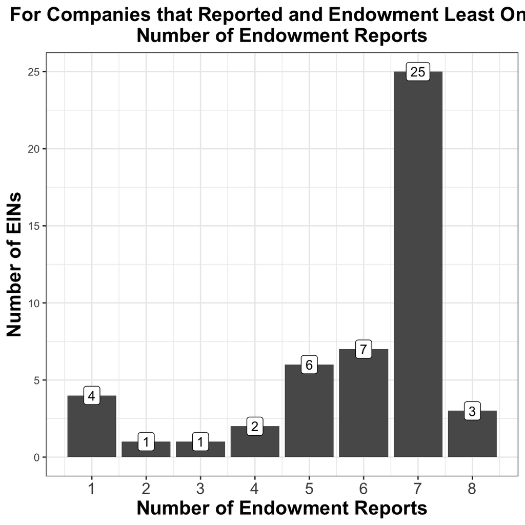

```r
# plot to show same information as previous table
filed_schd_d %>%
  select(EIN, Filled_Sch_D) %>%
  filter(Filled_Sch_D == "Yes") %>%
  group_by(EIN) %>%
  summarize(num_times_fil_sche_D = n()) %>%
  group_by(num_times_fil_sche_D) %>%
  summarize(num_ein = n()) %>%
  ggplot(aes(x = num_times_fil_sche_D, y = as.integer(num_ein))) +
  geom_bar(stat="identity") +
  scale_x_continuous(breaks = 1:8) +
  labs(title = "For Companies that Reported and Endowment Least Once,\nNumber of Endowment Reports",
       x = "Number of Endowment Reports",
       y = "Number of EINs") +
  geom_label(aes(label = num_ein)) +
  theme_bw() +
  theme(plot.title = element_text(size = 16, hjust = .5, face="bold"),
        plot.subtitle = element_text(hjust = .5, face="italic"),
        axis.text.x = element_text(size = 13),
        axis.title = element_text(size = 16, face = "bold"),
        legend.position = "none")
```

```r
# COMPANIES THAT NEVER REPORTED ENDOWMENT
all_eins <- filed_schd_d %>%
  select(EIN) %>%
  distinct()

# EINs that reported endowments
reported_eins <- filed_schd_d %>%
  filter(Filled_Sch_D == "Yes") %>%
  select(EIN) %>%
  distinct()

# Finding EINs that did NOT report endowments
never_reported_eins <- setdiff(all_eins, reported_eins)

# Joining with names to get organization names
never_reported_eins <- never_reported_eins %>%
  left_join(names, by = "EIN") %>%
  select(EIN, organization_name) %>%
  mutate(num_times_fil_sche_D = 0)  # Adding a column to show no filings

# Create a table to display the result
never_reported_eins %>%
  kable("html", booktabs = TRUE) %>%
  kable_styling(full_width = FALSE) %>%
  scroll_box(width = "100%", height = "450px") %>%
  kableExtra::footnote(general = "This table lists EINs that have never reported an endowment.")
```

| EIN | organization_name | num_times_fil_sche_D |
| --- | --- | --- |
| 860717486 | State Street Ballet | 0 |
| 611329176 | Kentucky Ballet Theatre | 0 |
| 942711919 | Post:ballet | 0 |
| 270524329 | Ballet Frontier | 0 |
| 453508749 | Ballet Next | 0 |
| 454864757 | Dissonance Dance Theatre | 0 |
| 061478674 | Mystic Ballet | 0 |
| 383945001 | Cleveland Ballet | 0 |
| 222354624 | Catskill Ballet Theatre | 0 |
| 134159687 | Ajkun Ballet Theatre | 0 |
| 274932963 | Texture Contemporary Ballet | 0 |
| 640732185 | Ballet Magnificat! | 0 |
| 431756712 | Missouri Contemporary Ballet | 0 |
| 880491536 | Sierra Nevada Ballet | 0 |
| 650804935 | Arts Ballet Theatre of Florida | 0 |
| 161328541 | Rochester City Ballet | 0 |
| 341645238 | Ohio Contemporary Ballet (Verb Ballets) | 0 |
| 311784286 | BalletX | 0 |
| 342066059 | Indianapolis Ballet | 0 |
| 416055588 | The Minnesota Ballet | 0 |
| 521151372 | Ballet Theatre of Maryland | 0 |
| 237161084 | PHILADANCO! | 0 |
| 522444709 | Lemon Sponge Cake Contemporary Ballet | 0 |
| 710508968 | Ballet Arkansas | 0 |
| 042773619 | Jose Mateo Ballet Theatre | 0 |
| 452960043 | Ballet des Ameriques | 0 |
| 050377245 | Ballet Rhode Island (Festival Ballet Providence | 0 |
| 010420070 | Maine State Ballet | 0 |
| 046193015 | Albany Berkshire Ballet | 0 |
| 222587551 | Newport Contemporary Ballet (Island Moving Company | 0 |

[output cut: 102 more lines]

Note:

This table lists EINs that have never reported an endowment.

```r
# Finding EINs that did NOT report endowments
never_reported_eins <- setdiff(all_eins, reported_eins)

# Counting the number of companies that never reported an endowment
num_never_reported <- nrow(never_reported_eins)

# Print the count
print(paste("Number of companies that never reported an endowment:", num_never_reported))
```

```
## [1] "Number of companies that never reported an endowment: 132"
```

There are 49 EINs which, at one point, have filled out Schedule D.

```r
#How many unique schedule D's are there
filed_schd_d %>%
 select(EIN, Filled_Sch_D) %>%
  filter(Filled_Sch_D == "Yes") %>%
  summarize(num_sch_d = n()) %>%
  make_table(title = "Total Number of Unique Endowment Reports", col_names = c("Total"))  %>%
  row_spec(row = 0:1, align = "center")
```

**Total Number of Unique Endowment Reports**

| Total |
| --- |
| 288 |

There are 288 uniquely filed Schedule D’s.

```r
filed_schd_d %>%
  select(TaxPeriodEndDt, EIN, Filled_Sch_D) %>%
  filter(Filled_Sch_D == "Yes") %>%
  mutate(year = substr(TaxPeriodEndDt, 1, 4)) %>%
  group_by(year) %>%
  summarize(num_sch_d_in_year = n()) %>%
  arrange(desc(year)) %>%
  make_table(title = "Years with Endowment Reported", col_names = c("Year", "Total Endowments Reported filed within the year"))
```

**Years with Endowment Reported**

| Year | Total Endowments Reported filed within the year |
| --- | --- |
| 2023 | 9 |
| 2022 | 41 |
| 2021 | 41 |
| 2020 | 44 |
| 2019 | 40 |
| 2018 | 40 |
| 2017 | 42 |
| 2016 | 31 |

## Determining Which Needed to File Schedule D for Endowment

Not all those that fill out schedule D do so for endowment, so I focused on Question 10 “Did the organization, directly or through a related organization, hold assets in temporarily restricted endowments, permanent endowments, or quasi endowments? If”yes,” complete Schedule D, Part V”.

```r
##Counting those that needed to fill schedule D
filed_schd_d %>%
  group_by(Need_Sch_D) %>%
  summarize(n = n()) %>%
  arrange(desc(Need_Sch_D)) %>%
  make_table(title = "Total EINs checked YES on Q10", col_names = c("Need Schedule D on Q10", "Total Filings"))
```

**Total EINs checked YES on Q10**

| Need Schedule D on Q10 | Total Filings |
| --- | --- |
| Yes | 134 |
| No | 378 |
| NA | 542 |

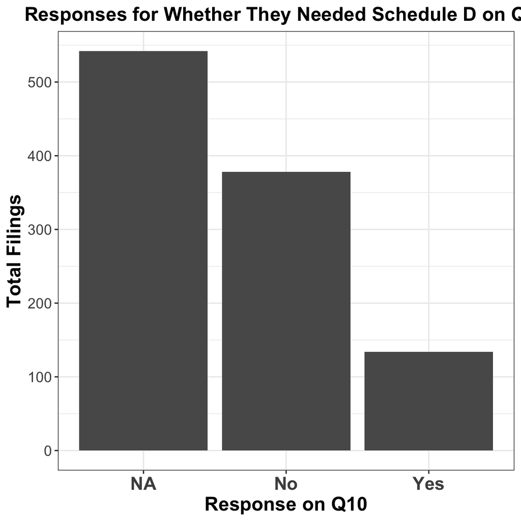

```r
# plot showing same information as previous table
filed_schd_d %>%
  group_by(Need_Sch_D) %>%
  summarize(`Total Filings` = n()) %>%
  arrange(desc(Need_Sch_D)) %>%
  ggplot(aes(x = Need_Sch_D, y = `Total Filings`)) +
  geom_bar(stat="identity") +
  theme_bw() +
  theme(plot.title = element_text(size = 16, hjust = .5, face="bold"),
        plot.subtitle = element_text(hjust = .5, face="italic"),
        axis.text.x = element_text(size = 15, face="bold"),
        axis.text.y = element_text(size = 12),
        axis.title = element_text(size = 16, face = "bold")) +
  labs(x = "Response on Q10",
       title = "Responses for Whether They Needed Schedule D on Q10") +
  scale_y_continuous(n.breaks = 6)
```

```r
##Seeing those that DID and or DID NOT need to fill out Schedule D, yet Did or Did Not
filed_schd_d %>%
  group_by(Need_Sch_D, Filled_Sch_D) %>%
  summarize(n = n()) %>%
  arrange(desc(Need_Sch_D)) %>%
  make_table(title = "Whether Individual 990 Filings Reported An Endowment", col_names = c("Needed to Report an Endowment", "Reported an Endowment", "Total Reports"))
```

**Whether Individual 990 Filings Reported An Endowment**

| Needed to Report an Endowment | Reported an Endowment | Total Reports |
| --- | --- | --- |
| Yes | Yes | 134 |
| No | No | 375 |
| No | Yes | 3 |
| NA | No | 391 |
| NA | Yes | 151 |

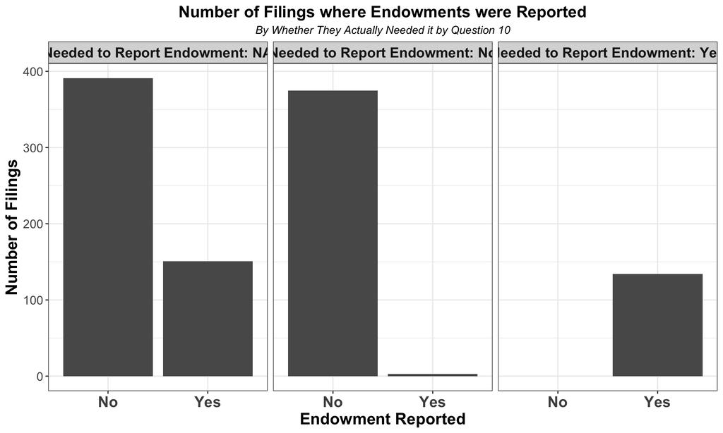

```r
# bar plot with same information as table above
filed_schd_d %>%
  group_by(Need_Sch_D, Filled_Sch_D) %>%
  summarize(n = n()) %>%
  arrange(desc(Need_Sch_D)) %>%
  ungroup() %>%
  mutate(Need_Sch_D = paste0("Needed to Report Endowment: ", Need_Sch_D)) %>%
  ggplot(aes(x = Filled_Sch_D, y = n)) +
  geom_bar(stat="identity") +
  facet_wrap(~Need_Sch_D) +
  theme_bw() +
  theme(plot.title = element_text(size = 16, hjust = .5, face="bold"),
        plot.subtitle = element_text(hjust = .5, face="italic"),
        axis.text.x = element_text(size = 15, face="bold"),
        axis.text.y = element_text(size = 12),
        axis.title = element_text(size = 16, face = "bold"),
        strip.text = element_text(face="bold",size = 14)) +
  labs(title = "Number of Filings where Endowments were Reported",
       subtitle = "By Whether They Actually Needed it by Question 10",
       x = "Endowment Reported",
       y = "Number of Filings")
```

# Examining Gaps in Filing Schedule D’s

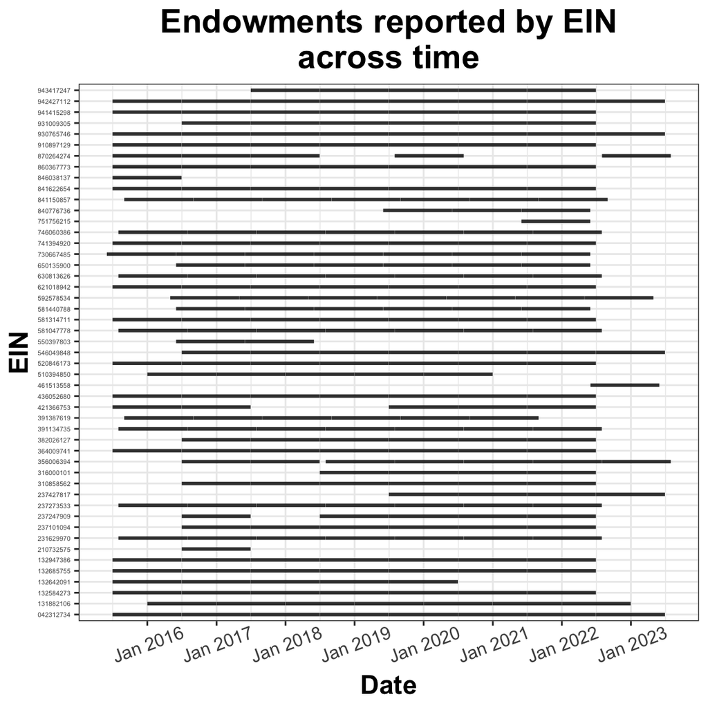

```r
filed_schd_d %>%
  filter(Filled_Sch_D == "Yes") %>%
  mutate(time = interval(TaxPeriodBeginDt, TaxPeriodEndDt),
         time = as.numeric(time, "days")) %>%
  group_by(EIN) %>%
  ggplot(aes(xmin = as.Date(TaxPeriodBeginDt, "%Y-%m-%d"),
             xmax = TaxPeriodEndDt,
             y = EIN)) +
  geom_linerange(linewidth = 1, alpha = .8) +
  theme_bw() +
  theme(plot.title = element_text(size = 20, face = "bold", hjust = .5),
        axis.title = element_text(size = 16, face = "bold"),
        plot.subtitle = element_text(size = 16, face = "italic", hjust = .5),
        axis.text.x = element_text(size = 11,angle=20, vjust = .7),
        axis.text.y = element_text(size = 4),
        strip.text = element_text(face="bold",size = 18)) +
  scale_x_date(date_breaks = "12 months",
               date_labels = "%b %Y") +
  labs(y = "EIN",
       x = "Date",
       title = "Endowments reported by EIN\nacross time")
```

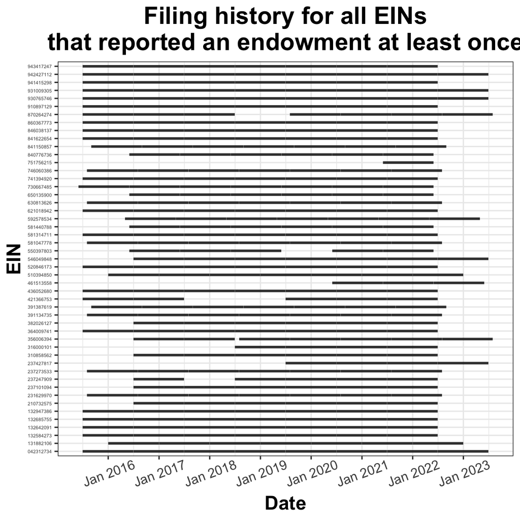

```r
#Getting EINS of those who have filled out Schedule D
ein_with_sch_d <- filed_schd_d %>%
  filter(Filled_Sch_D == "Yes") %>%
  pull(EIN) %>%
  unique()

#Gap plot
filed_schd_d %>%
  filter(EIN %in% ein_with_sch_d) %>%
  mutate(time = interval(TaxPeriodBeginDt, TaxPeriodEndDt),
         time = as.numeric(time, "days")) %>%
  group_by(EIN) %>%
  ggplot(aes(xmin = as.Date(TaxPeriodBeginDt, "%Y-%m-%d"),
             xmax = TaxPeriodEndDt,
             y = EIN)) +
  geom_linerange(linewidth = 1, alpha = .8) +
  theme_bw() +
  theme(plot.title = element_text(size = 20, face = "bold", hjust = .5),
        axis.title = element_text(size = 16, face = "bold"),
        plot.subtitle = element_text(size = 16, face = "italic", hjust = .5),
        axis.text.x = element_text(size = 11,angle=20, vjust = .7),
        axis.text.y = element_text(size = 4),
        strip.text = element_text(face="bold",size = 18)) +
  scale_x_date(date_breaks = "12 months",
               date_labels = "%b %Y") +
  labs(y = "EIN",
       x = "Date",
       title = "Filing history for all EINs\nthat reported an endowment at least once")
```

```r
#Retrieving list of schedule D filing gaps
filed_schd_d %>%
  filter(EIN %in% ein_with_sch_d & Filled_Sch_D == "Yes") %>%
  select(EIN,
         TaxPeriodBeginDt, #calc dates b/w schedule d
         TaxPeriodEndDt) %>%
  group_by(EIN) %>%
  arrange(TaxPeriodBeginDt) %>%
  mutate(before =  lag(TaxPeriodEndDt, n =1),
        gap = interval(before, TaxPeriodBeginDt),
        gap = as.numeric(gap, "days")) %>%
  filter(gap > 1) %>%
  left_join(names, by = "EIN") %>%
  select(EIN, organization_name, gap, before, TaxPeriodBeginDt) %>%
  make_table(title = "Endowment Reporting Gaps", col_names = c("EIN", "Organization Name", "Gap Length (Days)", "Gap Start Date", "Gap End Date"))
```

**Endowment Reporting Gaps**

| EIN | Organization Name | Gap Length (Days) | Gap Start Date | Gap End Date |
| --- | --- | --- | --- | --- |
| 237247909 | New Mexico Ballet Company | 366 | 2017-06-30 | 2018-07-01 |
| 356006394 | Fort Wayne Ballet | 32 | 2018-06-30 | 2018-08-01 |
| 421366753 | Ballet Quad Cities | 731 | 2017-06-30 | 2019-07-01 |
| 870264274 | Ballet West | 397 | 2018-06-30 | 2019-08-01 |
| 870264274 | Ballet West | 731 | 2020-07-31 | 2022-08-01 |

```r
#Retrieving list of 990 filing gaps, for those who have once filled out an EIN
filed_schd_d %>%
  filter(EIN %in% ein_with_sch_d) %>%
  select(EIN,
         TaxPeriodBeginDt,
         TaxPeriodEndDt) %>%
  group_by(EIN) %>%
  arrange(TaxPeriodBeginDt) %>%
  mutate(before =  lag(TaxPeriodEndDt, n =1),
        gap = interval(before, TaxPeriodBeginDt),
        gap = as.numeric(gap, "days")) %>%
  filter(gap > 1) %>%
  left_join(names, by = "EIN") %>%
  select(EIN, organization_name, gap, before, TaxPeriodBeginDt) %>%
  make_table(title = "990 Filing Gaps for EINs\nwhich once reported an Endowment", col_names = c("EIN", "Organization Name", "Gap Length (Days)", "Gap Start Date", "Gap End Date"))
```

**990 Filing Gaps for EINs which once reported an Endowment**

| EIN | Organization Name | Gap Length (Days) | Gap Start Date | Gap End Date |
| --- | --- | --- | --- | --- |
| 237247909 | New Mexico Ballet Company | 366 | 2017-06-30 | 2018-07-01 |
| 356006394 | Fort Wayne Ballet | 32 | 2018-06-30 | 2018-08-01 |
| 421366753 | Ballet Quad Cities | 731 | 2017-06-30 | 2019-07-01 |
| 870264274 | Ballet West | 397 | 2018-06-30 | 2019-08-01 |
| 550397803 | The Charleston Ballet | 367 | 2019-05-31 | 2020-06-01 |

# Aligning 990 Filing Gaps and Schedule D Filing Gaps

Important note: Filing Schedule D guarantees they filed a 990.

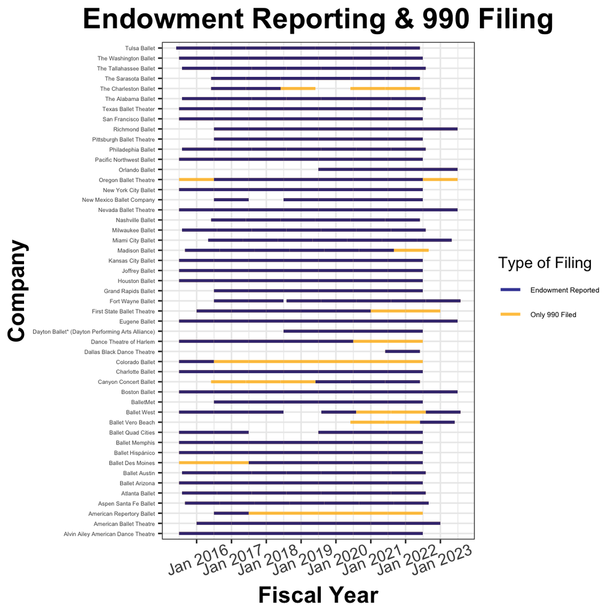

```r
##Plotting both 990 gaps and Schedule D Gaps
schd_d_gap <- filed_schd_d %>%
  filter(Filled_Sch_D == "Yes") %>%
  mutate(time = interval(TaxPeriodBeginDt, TaxPeriodEndDt),
         time = as.numeric(time, "days")) %>%
  group_by(EIN) %>%
  mutate(sum_coverage = sum(time),
         type = "Endowment Reported")

##Gap plot
gap_plot_fr <- filed_schd_d %>%
  filter(EIN %in% ein_with_sch_d) %>%
  mutate(time = interval(TaxPeriodBeginDt, TaxPeriodEndDt),
         time = as.numeric(time, "days")) %>%
  group_by(EIN) %>%
  mutate(sum_coverage = sum(time),
         type = "Only 990 Filed") %>%
  bind_rows(schd_d_gap) %>%
  left_join(names, by = "EIN") %>%
  ggplot(aes(xmin = as.Date(TaxPeriodBeginDt, "%Y-%m-%d"),
             xmax = TaxPeriodEndDt,
             y = organization_name,
             color = type)) +
  geom_linerange(linewidth = 1, alpha = .8) +
  theme_bw() +
  theme(plot.title = element_text(size = 20, face = "bold", hjust = .5),
        axis.title = element_text(size = 16, face = "bold"),
        plot.subtitle = element_text(size = 16, face = "italic", hjust = .5),
        axis.text.x = element_text(size = 11,angle=20, vjust = .7),
        axis.text.y = element_text(size = 4),
        strip.text = element_text(face="bold",size = 18),
        legend.text = element_text(size = 5)) +
  scale_x_date(date_breaks = "12 months",
               date_labels = "%b %Y") +
  scale_color_manual(values = c("blue4", "darkgoldenrod1")) +
  labs(y = "Company",
       x = "Fiscal Year",
       title = "Endowment Reporting & 990 Filing",
       color = "Type of Filing")
gap_plot_fr
```

```r
## Table Identifying those that don't line up
filed_schd_d %>%
  filter(EIN %in% ein_with_sch_d) %>%
  mutate(time = interval(TaxPeriodBeginDt, TaxPeriodEndDt),
         time = as.numeric(time, "days")) %>%
  group_by(EIN) %>%
  mutate(sum_coverage = sum(time),
         type = "Only 990 Filed") %>%
  bind_rows(schd_d_gap) %>%
  group_by(EIN) %>%
  arrange(EIN, type, TaxPeriodBeginDt) %>%
  select(-type) %>%
  anyDuplicated()
```

```
## [1] 9
```

```r
filed_schd_d %>%
  filter(EIN %in% ein_with_sch_d) %>%
  mutate(time = interval(TaxPeriodBeginDt, TaxPeriodEndDt),
         time = as.numeric(time, "days")) %>%
  group_by(EIN) %>%
  mutate(sum_coverage = sum(time),
         type = "Only 990 Filed") %>%
  bind_rows(schd_d_gap) %>%
  select(-c(type, time, sum_coverage)) %>%
  group_by(TaxPeriodBeginDt, TaxPeriodEndDt, ReturnDate, EIN, Filled_Sch_D, Need_Sch_D) %>%
  mutate(num_dups = n()) %>%
  filter(num_dups < 2) %>%
  left_join(names, by = "EIN") %>%
  group_by(EIN, organization_name) %>%
  summarize() %>%
  make_table(title = "EINS that filled out Schedule D sometimes,\nbut not always", col_names = c("EIN", "Organization Name"))
```

**EINS that filled out Schedule D sometimes, but not always**

| EIN | Organization Name |
| --- | --- |
| 132642091 | Dance Theatre of Harlem |
| 210732575 | American Repertory Ballet |
| 391387619 | Madison Ballet |
| 461513558 | Ballet Vero Beach |
| 510394850 | First State Ballet Theatre |
| 550397803 | The Charleston Ballet |
| 840776736 | Canyon Concert Ballet |
| 846038137 | Colorado Ballet |
| 870264274 | Ballet West |
| 931009305 | Oregon Ballet Theatre |
| 943417247 | Ballet Des Moines |

# Checking Endowment Reporting - Is the Math Right?

```r
## Using Quinn's endowment data
endowment_data <- read_rds(here("data", "endowments_by_most_recent_filings.RDS"))
```

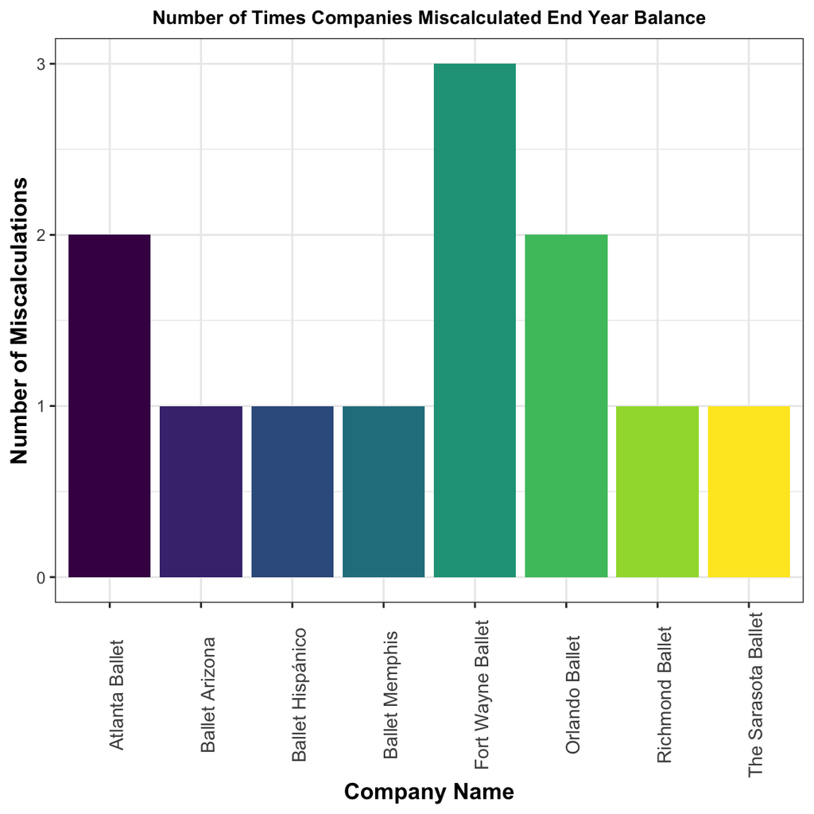

```r
## NOTE:  ASSUMING NA IS ZERO FOR THE SAKE OF THE CALCULATIONS
# Finding differences in calculation and report

endowment_data$BeginningYearBalanceAmt <- as.numeric(as.character(endowment_data$BeginningYearBalanceAmt))
endowment_data$ContributionsAmt <- as.numeric(as.character(endowment_data$ContributionsAmt))
endowment_data$OtherExpendituresAmt <- as.numeric(as.character(endowment_data$OtherExpendituresAmt))
endowment_data$AdministrativeExpensesAmt <- as.numeric(as.character(endowment_data$AdministrativeExpensesAmt))
endowment_data$GrantsOrScholarshipsAmt <- as.numeric(as.character(endowment_data$GrantsOrScholarshipsAmt))
endowment_data$InvestmentEarningsOrLossesAmt <- as.numeric(as.character(endowment_data$InvestmentEarningsOrLossesAmt))
endowment_data$EndYearBalanceAmt <- as.numeric(as.character(endowment_data$EndYearBalanceAmt))

test_diff <- endowment_data %>%
  mutate(across(.cols = 3:9, ~ ifelse(is.na(.), 0, .))) %>%
  mutate(end_bal_calc = (BeginningYearBalanceAmt +
           ContributionsAmt + InvestmentEarningsOrLossesAmt -
           abs(OtherExpendituresAmt) - abs(AdministrativeExpensesAmt) - abs(GrantsOrScholarshipsAmt)),
         same_end = ifelse(end_bal_calc == EndYearBalanceAmt, TRUE, FALSE),
         diff_end = EndYearBalanceAmt - end_bal_calc)

## MEAGHAN FIX THIS CODE BLOCK
## as_tibble validate vs name_repair error

# Looking at differences
# test_diff %>%
#   filter(same_end == FALSE) %>%
# #  arrange(desc(abs(diff_end))) %>%
#   left_join(names, by = "EIN") %>%
#   select(organization_name, fiscal_year, EndYearBalanceAmt, end_bal_calc, diff_end) %>%
#   make_table("Differences in Reported End Year Balances",
#              col_names = c("Organization Name", "Year", "Reported End Balance",
#                            "Calculated End Balance", "Difference")) %>%
#   scroll_box(height = "450px")

## Misreports by company
test_diff %>%
  filter(same_end == FALSE) %>%
  left_join(names, by = "EIN") %>%
  ggplot(aes(x = organization_name)) +
  geom_bar(aes(fill = organization_name), show.legend = FALSE) +
  theme_bw() +
  theme(plot.title = element_text(size = 10, face = "bold", hjust = .5),
        axis.title = element_text(size = 12, face = "bold"),
        plot.subtitle = element_text(size = 5, face = "italic", hjust = .5),
        axis.text.x = element_text(size = 10, angle = 90),
        strip.text = element_text(face="bold",size = 5),
        legend.key.size = unit(1, 'mm'),
        legend.text = element_text(size=7)) +
  scale_fill_viridis_d() +
  labs( title = "Number of Times Companies Miscalculated End Year Balance",
        y = "Number of Miscalculations",
        x = "Company Name")
```

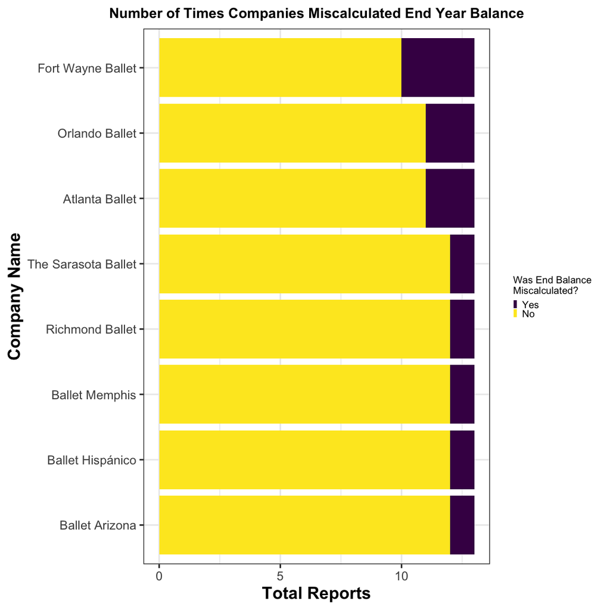

```r
## Proportion of misreports by company
##List of companies
companies_miscalculate <- test_diff %>%
  filter(same_end == FALSE) %>%
  left_join(names, by = "EIN") %>%
  group_by(organization_name) %>%
  summarize(n = n()) %>%
  arrange(n) %>%
  pull(organization_name) %>%
  unique()

## Counts per company
counts <- test_diff %>%
  left_join(names, by = "EIN") %>%
  filter(same_end == FALSE) %>%
  group_by(organization_name) %>%
  summarize(n = n())

hist_diff_fr <- test_diff %>%
  left_join(names, by = "EIN") %>%
  mutate(organization_name = factor(organization_name, level = companies_miscalculate)) %>%
  filter(organization_name %in% c(companies_miscalculate)) %>%
  ggplot(aes(x = organization_name, fill = same_end)) +
  geom_bar() +
  theme_bw() +
  theme(plot.title = element_text(size = 10, face = "bold", hjust = .5),
        axis.title = element_text(size = 12, face = "bold"),
        plot.subtitle = element_text(size = 5, face = "italic", hjust = .5),
        strip.text = element_text(face="bold",size = 5),
        legend.key.size = unit(1, 'mm'),
        legend.text = element_text(size=7),
        legend.title = element_text(size = 7)) +
  scale_fill_viridis_d(labels = c("Yes", "No")) +
  labs( title = "Number of Times Companies Miscalculated End Year Balance",
        y = "Total Reports",
        x = "Company Name",
        fill = "Was End Balance \nMiscalculated?") +
  coord_flip()
hist_diff_fr
```

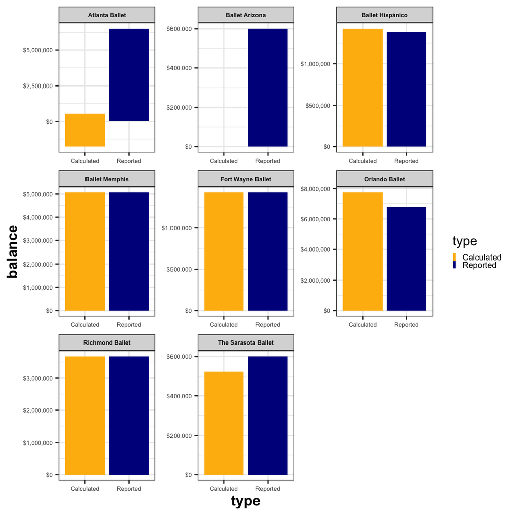

```r
#Histograms of all misreports compared (sorta)
test_diff %>%
  filter(same_end == FALSE) %>%
  left_join(names, by = "EIN") %>%
  select(EIN, fiscal_year, organization_name, EndYearBalanceAmt, end_bal_calc) %>%
  pivot_longer(cols = c(EndYearBalanceAmt, end_bal_calc),
               names_to = "type",
               values_to = "balance") %>%
  mutate(type = ifelse(type == "EndYearBalanceAmt", "Reported", "Calculated")) %>%
  ggplot(aes(x = type, y = balance, fill = type)) +
  geom_col(position = "dodge") +
  facet_wrap(~organization_name, scales = "free") +
  theme_bw() +
    theme(plot.title = element_text(size = 10, face = "bold", hjust = .5),
        axis.title = element_text(size = 12, face = "bold"),
        plot.subtitle = element_text(size = 5, face = "italic", hjust = .5),
        axis.text.x = element_text(size = 5),
        axis.text.y = element_text(size = 5),
        strip.text = element_text(face="bold",size = 5),
        legend.key.size = unit(1, 'mm'),
        legend.text = element_text(size=7)) +
  scale_y_continuous(labels = scales::label_dollar()) +
  scale_fill_manual(values = c("darkgoldenrod1", "blue4"))
```

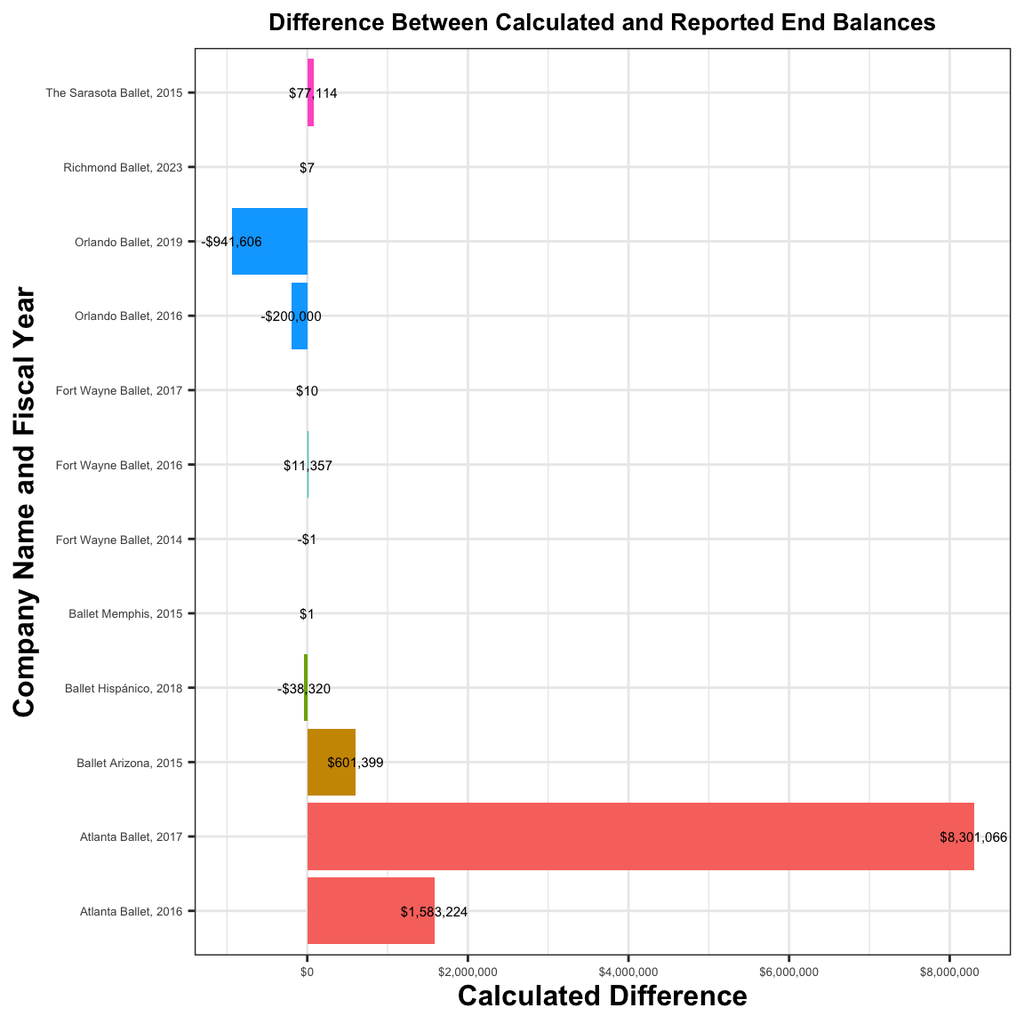

```r
# Difference Plotted
calc_diff <- test_diff %>%
  filter(same_end == FALSE) %>%
  left_join(names, by = "EIN") %>%
  select(EIN, fiscal_year, organization_name, EndYearBalanceAmt, diff_end) %>%
  mutate(name = paste(organization_name, fiscal_year, sep = ", ")) %>%
  ggplot(aes(y = name, x = diff_end, fill = organization_name)) +
  geom_col(position = "dodge", show.legend = FALSE) +
  #facet_wrap(~organization_name, scales = "free") +
  theme_bw() +
    theme(plot.title = element_text(size = 10, face = "bold", hjust = .5),
        axis.title = element_text(size = 12, face = "bold"),
        plot.subtitle = element_text(size = 5, face = "italic", hjust = .5),
        axis.text.x = element_text(size = 5),
        axis.text.y = element_text(size = 5),
        strip.text = element_text(face="bold",size = 5),
        legend.key.size = unit(1, 'mm'),
        legend.text = element_text(size=7)) +
  scale_x_continuous(labels = scales::label_dollar()) +
 # scale_fill_manual(values = pal)+
  labs(title = "Difference Between Calculated and Reported End Balances",
       x = "Calculated Difference",
       y = "Company Name and Fiscal Year") +
  geom_text(aes(label = scales::dollar(diff_end)), size = 2)
calc_diff
```

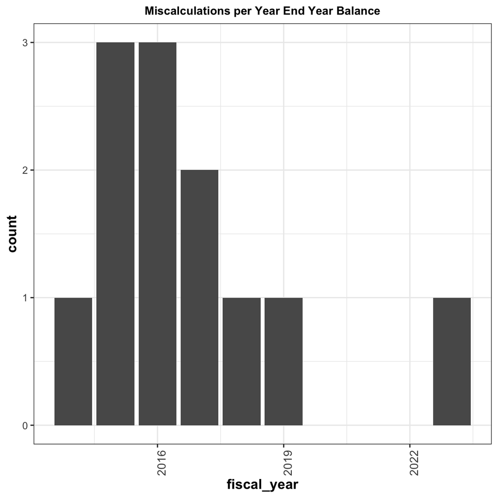

```r
# Relationship between year and misreports?  No
test_diff %>%
  filter(same_end == FALSE) %>%
  left_join(names, by = "EIN") %>%
  ggplot(aes(x = fiscal_year)) +
  geom_bar() +
  theme_bw() +
  theme(plot.title = element_text(size = 10, face = "bold", hjust = .5),
        axis.title = element_text(size = 12, face = "bold"),
        plot.subtitle = element_text(size = 5, face = "italic", hjust = .5),
        axis.text.x = element_text(size = 10, angle = 90),
        strip.text = element_text(face="bold",size = 5),
        legend.key.size = unit(1, 'mm'),
        legend.text = element_text(size=7)) +
  labs( title = "Miscalculations per Year End Year Balance")
```

```r
##MEAGHAN FIX THIS CODE BLOCK
## same problem as above

## Table showing same information as plot above, total miscalculations
# test_diff %>%
#   filter(same_end == FALSE) %>%
#   arrange(desc(abs(diff_end))) %>%
#   left_join(names, by = "EIN") %>%
#   group_by(organization_name) %>%
#   summarize(n = n()) %>%
#   make_table("List of Misreported Companies",
#              col_names = c("Organization Name", "Total Miscalculations")) %>%
#   scroll_box(height = "450px")
```

```r
miscalculation_table <- test_diff %>%
  filter(same_end == FALSE) %>%
  left_join(names, by = "EIN") %>%
  select(fiscal_year, organization_name) %>%
  arrange(fiscal_year, organization_name) %>%
  rename(Year = fiscal_year, Company = organization_name) %>%
  distinct()

kable(miscalculation_table, format = "html", table.attr = "style='width:100%'") %>%
  kable_styling(bootstrap_options = c("striped", "hover"))
```

| Year | Company |
| --- | --- |
| 2014 | Fort Wayne Ballet |
| 2015 | Ballet Arizona |
| 2015 | Ballet Memphis |
| 2015 | The Sarasota Ballet |
| 2016 | Atlanta Ballet |
| 2016 | Fort Wayne Ballet |
| 2016 | Orlando Ballet |
| 2017 | Atlanta Ballet |
| 2017 | Fort Wayne Ballet |
| 2018 | Ballet Hispánico |
| 2019 | Orlando Ballet |
| 2023 | Richmond Ballet |

# Saving Relevant Images For Report

## Schedule D Gap Plot

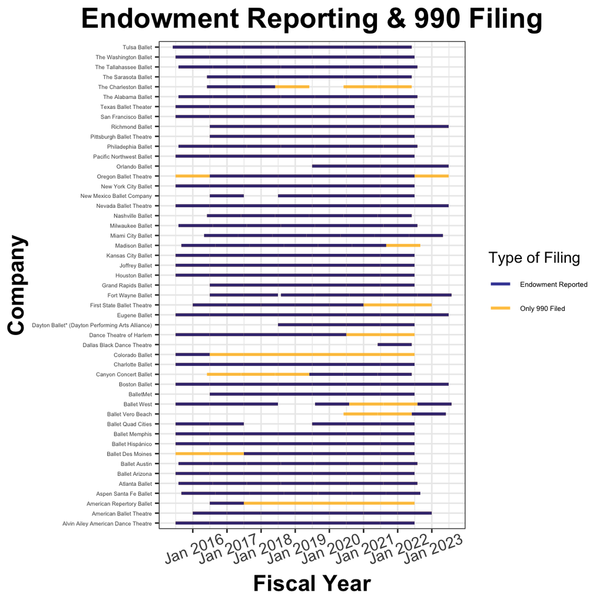

```r
gap_plot_fr
```

```r
ggsave("gap_plot_endowment.png", path = here("final_report", "images"))
```

## Reporting Consistencies

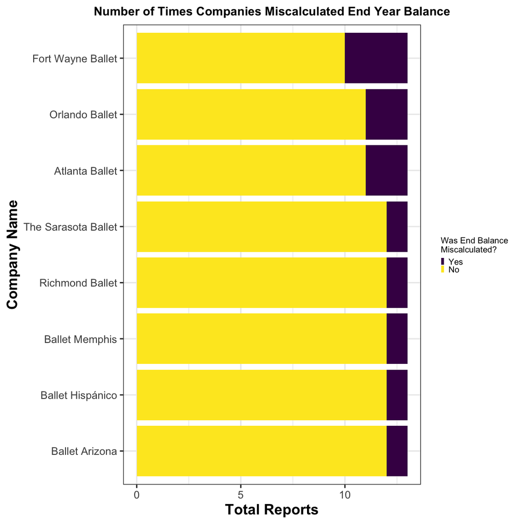

```r
hist_diff_fr
```

```r
ggsave("miscalc_end_bal.png", path = here("final_report", "images"))
```

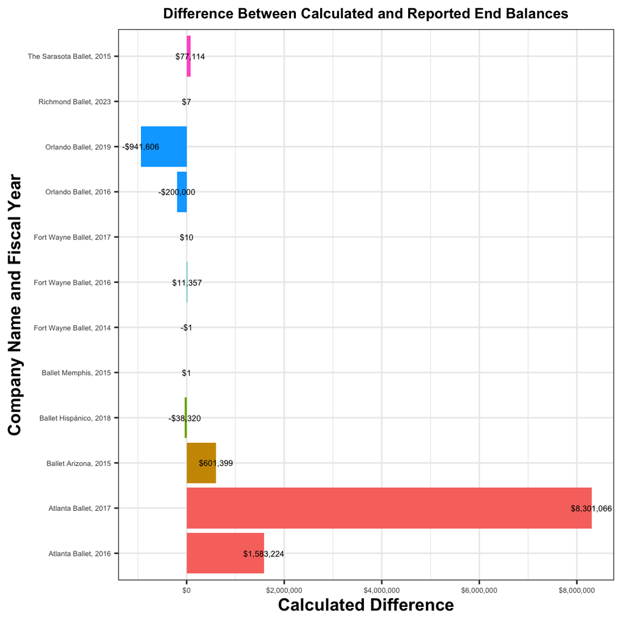

```r
calc_diff
```

```r
ggsave("diff_end_bal.png", path = here("final_report", "images"))
```